# ggplot2を利用したデータ可視化の基礎

藤野秀則,

2024-06-01

平均や分散、標準偏差、あるいは四分位数といった基本的な統計量の算出方法が分かったので、ここでggplot2というパッケージを用いたデータの可視化の方法の基礎について学習する。

# 1 ggplot2のインストール

ggplot2は美しい描画をしてくれる様々な関数を提供する外部パッケージである。利用するためには、データハンドリングで使った`tidyverse`を読み込む。データハンドリングの時に一度インストールをしているので、今度はスクリプトの冒頭に`library(tidyvers)`と書き入れるだけでよい。

```r
library(tidyverse)
```

ggplot2自体は「ggplot2」という名前のパッケージであり、インストールするパッケージも本来であれば「ggplot2」パッケージで良いのだが、「tidyverse」パッケージではggplot2を含め様々な便利なパッケージがまとめられている。後々それらのパッケージも利用していきたいので、ここではtidyverseパッケージを利用する。

# 2 ggplot2をつかった描画の基本的な流れ

Step1：データを与えて描画キャンバスを作る

↓

Step2：与えたデータに対して各種の描画命令を与える

↓

Step3：必要ならば凡例や軸の書式の設定をする

↓

Step4:`plot()`関数を実行する。

# 3 データの準備

ここでは、前回と同様にirisデータを使うことにする。

```r
data_iris <- iris
colnames(data_iris) <-  c("がく長","がく幅","花びら長","花びら幅","種類")
head(data_iris)
```

```
##   がく長 がく幅 花びら長 花びら幅   種類
## 1    5.1    3.5      1.4      0.2 setosa
## 2    4.9    3.0      1.4      0.2 setosa
## 3    4.7    3.2      1.3      0.2 setosa
## 4    4.6    3.1      1.5      0.2 setosa
## 5    5.0    3.6      1.4      0.2 setosa
## 6    5.4    3.9      1.7      0.4 setosa
```

# 4 キャンバスの作成

キャンバスの作成には`ggplot()`関数を用いる。引数にはデータを与える。

```r
g <- ggplot(data_iris)
```

これでキャンバスのオブジェクトが`g`という名前で格納された。この`g`に対して、色々な描画関数を与えていき、最後に`g`を`plot()`関数で実際に描画させる、というのが基本的な描画のフローとなる。

ちなみに現時点で`plot()`を実行すると以下のようになる。

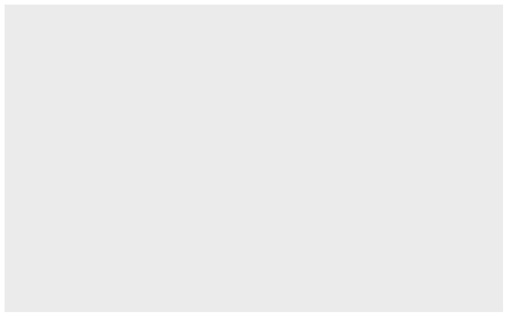

```r
plot(g)
```

このとおり、まだ中身がなにもないので描画エリアだけの描画となる。

# 5 描画関数の実行

## 5.1 箱ひげ図

まずはがく長の箱ひげ図を書かせることにしよう。

### 5.1.1 単純な箱ひげ図

箱ひげ図を書かせる命令は`geom_boxplot()`関数となる。この関数の第1引数に`aes()`関数をあたえる。`aes()`関数ではさらにy軸のデータを設定する。

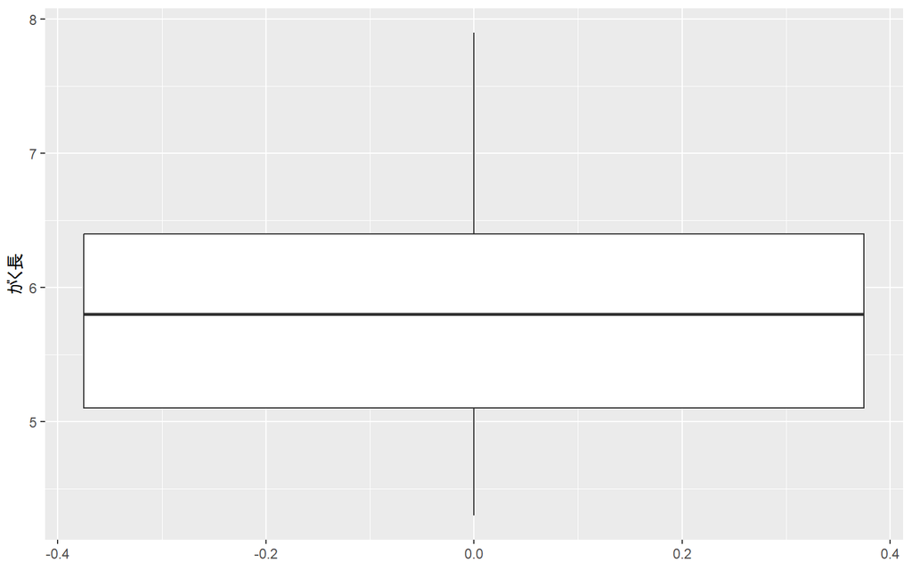

```r
g <- ggplot(data_iris) + geom_boxplot(aes(y=がく長))
plot(g)
```

y をxに返ると以下の通りとなる。

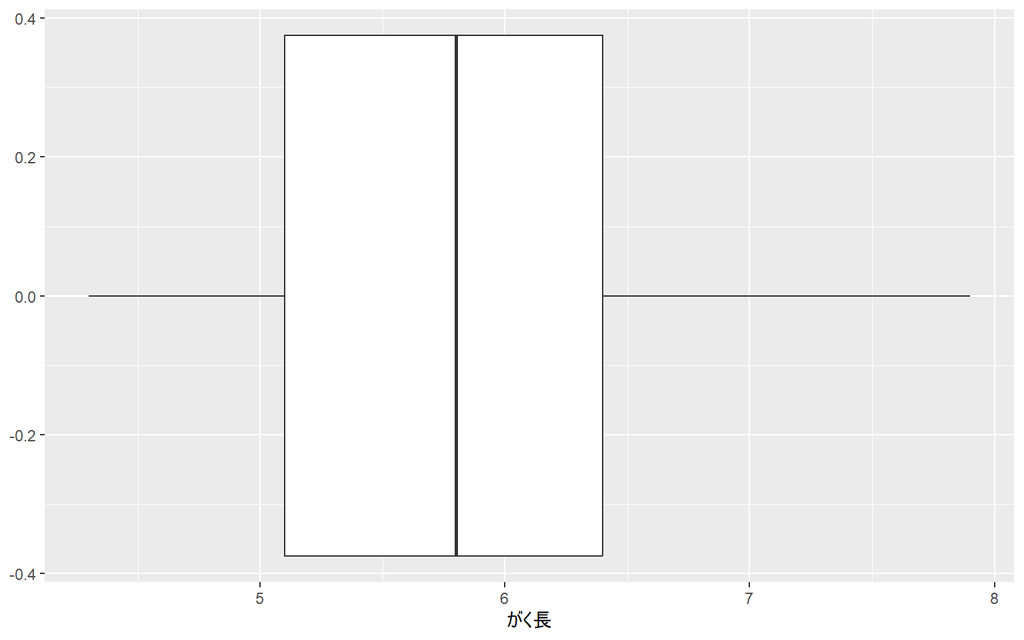

```r
g <- ggplot(data_iris) + geom_boxplot(aes(x=がく長))
plot(g)
```

### 5.1.2 種類ごとの箱ひげ図

上記はxないしはyのいずれかの軸しか設定していないが、例えば、x軸を種類に設定して、種類ごとの箱ひげ図を書かせたいといった場合には以下の通りにする。

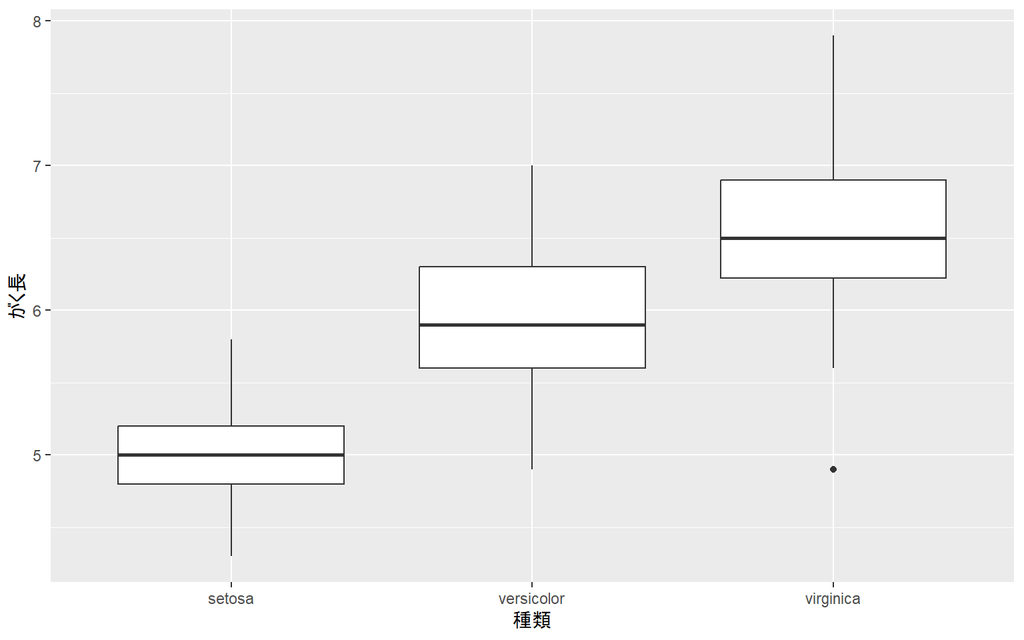

```r
g <- ggplot(data_iris) + geom_boxplot(aes(x=種類, y=がく長))
plot(g)
```

このように箱ひげ図が種類ごとに描かれる。

### 5.1.3 箱ひげ図へ塗色

箱ひげ図に色を塗りたい場合には、`aes()`に`fill`(塗りつぶし)の設定を与える。塗分けは箱ひげ図の場合にはグループ単位で行いたいであろう。そういう場合には、グループ分けに使っている変数、すなわち種類を与えると良い。

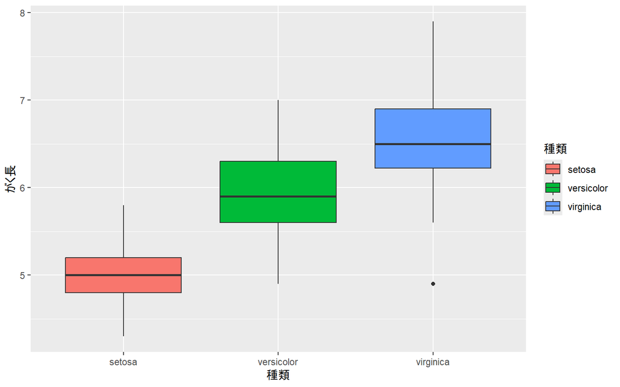

```r
g <- ggplot(data_iris) + geom_boxplot(aes(x=種類, y=がく長, fill=種類))
plot(g)
```

### 5.1.4 箱の幅を変える

`geom_boxplot()`の第2引数（`aes()`関数の外の引数）としてwidthを与える。デフォルトは0.75に設定されてる。

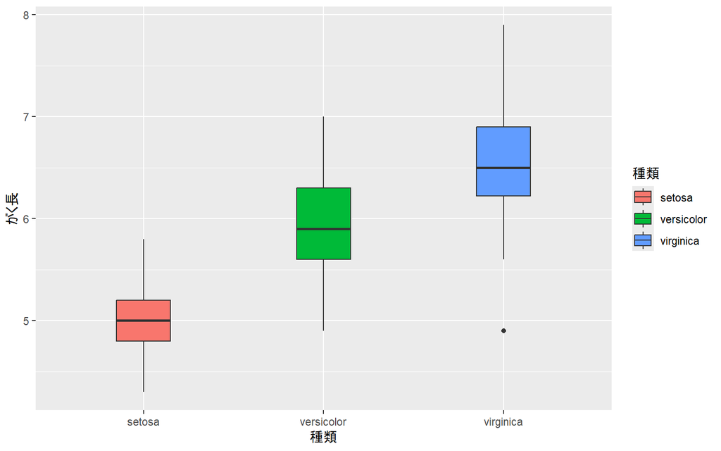

```r
g <- ggplot(data_iris) + geom_boxplot(aes(x=種類, y=がく長, fill=種類),width=0.3 )
plot(g)
```

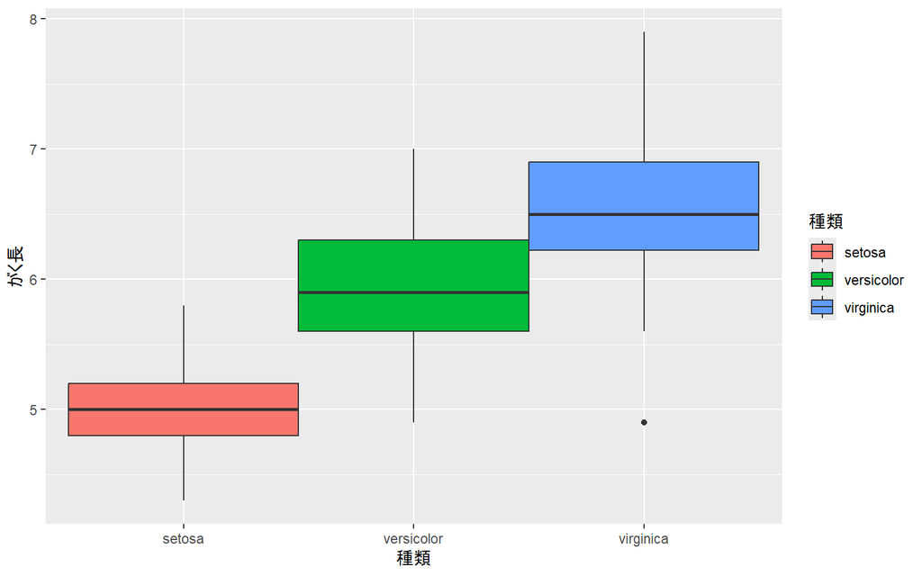

```r
g <- ggplot(data_iris) + geom_boxplot(aes(x=種類, y=がく長, fill=種類),width=1.0 )
plot(g)
```

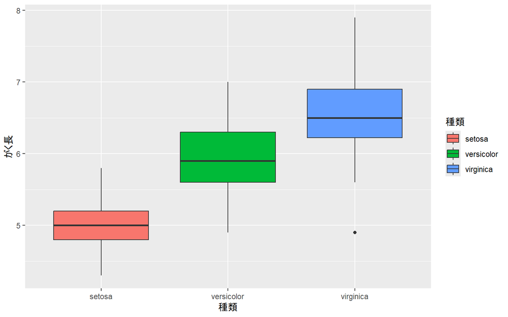

```r
g <- ggplot(data_iris) + geom_boxplot(aes(x=種類, y=がく長, fill=種類),width=0.75)
plot(g)
```

## 5.2 点プロット

`geom_jitter()`を使う。引数として`aes()`を使って同じようにx、yを設定する。

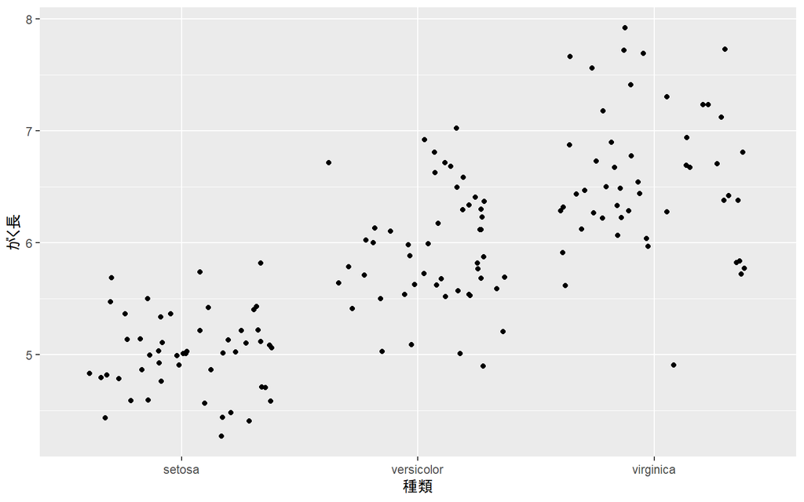

```r
g <- ggplot(data_iris)+geom_jitter(aes(x=種類, y=がく長))
plot(g)
```

y軸（がく長）については、それぞれ値を持っているが、x軸については3種類のグループ分けしかない。それをそのまま描画したのでは、同じがく長になっているものが全部重なってしまうので、そうならないように、x軸方向にランダムにバラつかせて描画されている。このx軸方向のバラつきは描画のたびにランダムに変わる。

もう一度描画させると、先ほどと違うばらつき方になる。

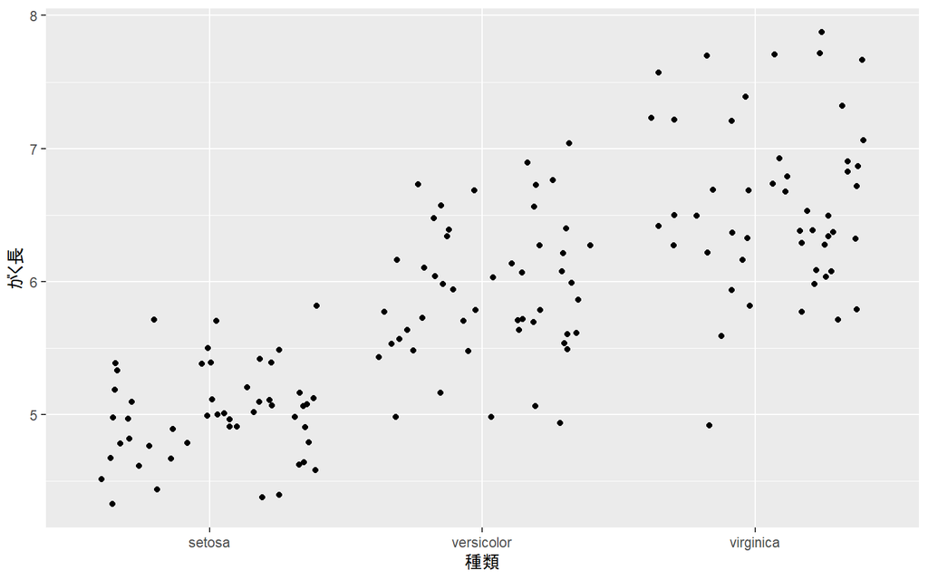

```r
g <- ggplot(data_iris)+geom_jitter(aes(x=種類, y=がく長))
plot(g)
```

### 5.2.1 色やプロット範囲の幅を変える

箱ひげ図の時と同様に、色や幅を変えることができる。色については`fill`（塗りつぶし）ではなく`color`を設定したり、`Width`を設定したりして、色や幅を変えることができる。

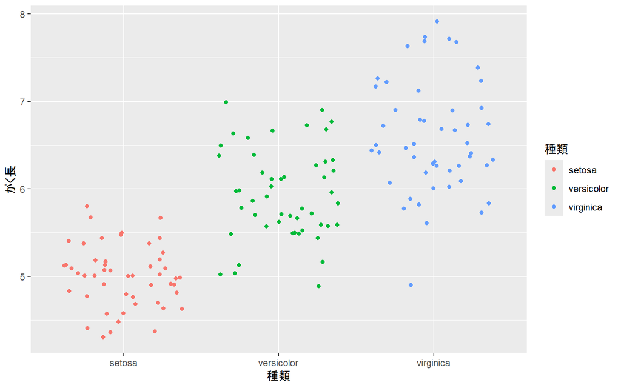

```r
g <- ggplot(data_iris)+geom_jitter(aes(x=種類, y=がく長, color=種類))
plot(g)
```

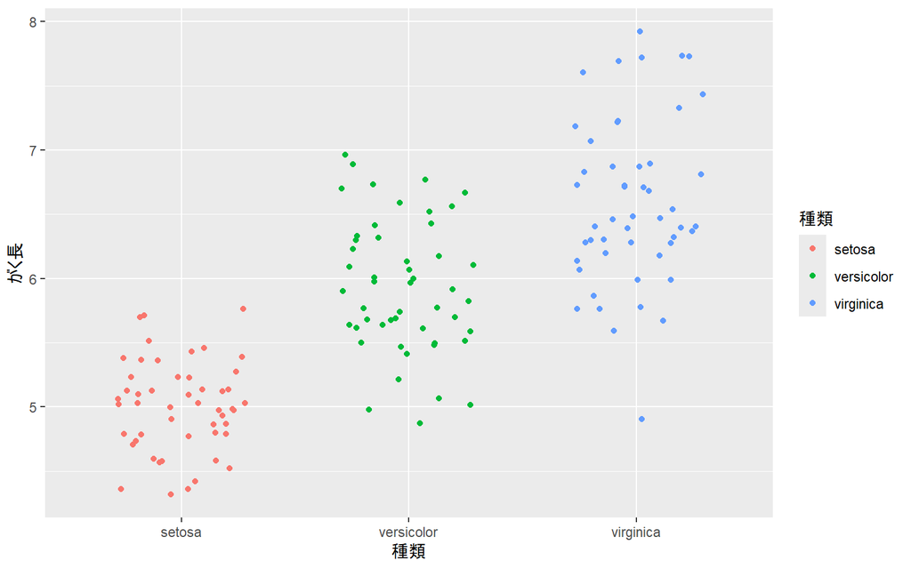

```r
g <- ggplot(data_iris)+geom_jitter(aes(x=種類, y=がく長, color=種類), width = 0.3)
plot(g)
```

### 5.2.2 Jitterではなく度数分布にする

先の例では点をプロットするときに横方向にランダム化させるjitter表示にしていたが、度数分布にすることもできる。 度数分布の場合には、`geom_jitter()`の代わりに`geom_dotplot()`関数を用いる。引数がやや多いので以下に表で示す。

| 引数名 | 内容 |
| --- | --- |
| aes(x=, y=) | x軸、y軸の設定 |
| binaxis | どちらの軸の変数についての度数分布にするのか |
| dotsize | プロットする点のサイズ |
| stackdir | どの方向にプロットしていくか。Up(右向き), down(左向き), center(中心ぞろえ)のいずれか |
| binwidth | 度数分布における区間幅の設定 |
| position | `position_nudge()`関数によって描画開始をそれぞれのグループのx軸の中心からどちら向き（正か負か）にどれだけ離すかの設定する。stackdirをcenterにした場合には中心がずれる |

以下に、実際にいくつか例示してみる。

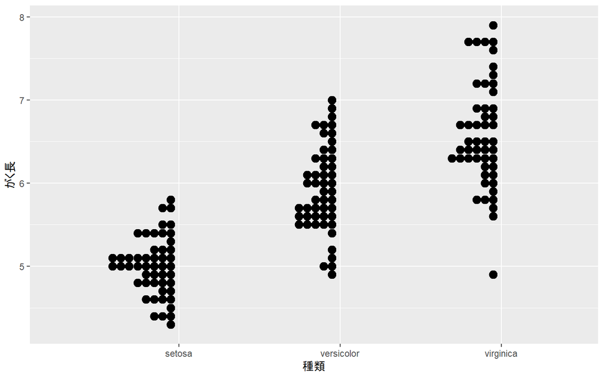

```r
g <- ggplot(data_iris)+
  geom_dotplot(aes(x=種類, y=がく長), binaxis = "y", dotsize = 1.0, stackdir = "down",
               binwidth = 0.1, position = position_nudge(-0.025))
plot(g)
```

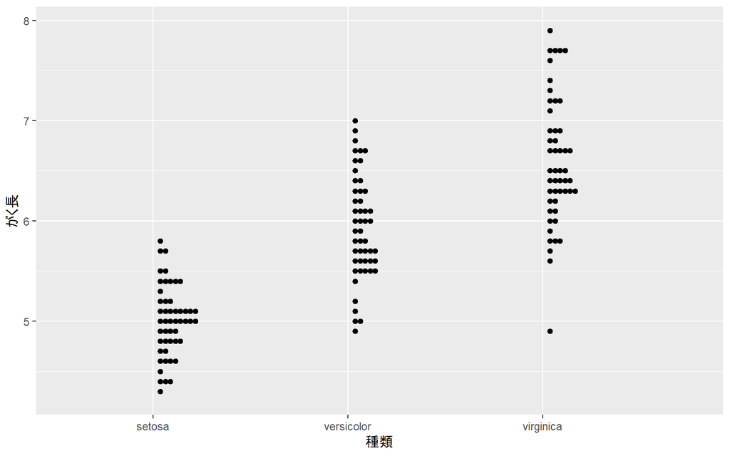

```r
g <- ggplot(data_iris)+
  geom_dotplot(aes(x=種類, y=がく長), binaxis = "y", dotsize = 0.50, stackdir = "up",
               binwidth = 0.1, position = position_nudge(0.025))
plot(g)
```

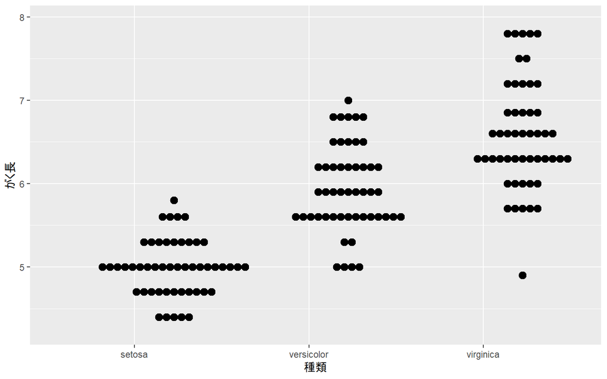

```r
g <- ggplot(data_iris)+
  geom_dotplot(aes(x=種類, y=がく長), binaxis = "y", dotsize = 0.3, stackdir = "center",
               binwidth = 0.3, position = position_nudge(0.225))
plot(g)
```

以下はbinaxisをxに設定しているためエラーとなる（xはグループ分け変数であり、概念上度数分布というものが存在しないので）。

```r
g <- ggplot(data_iris)+
  geom_dotplot(aes(x=種類, y=がく長), binaxis = "x", dotsize = 0.3, stackdir = "up",
               binwidth = 0.1, position = position_nudge(0.025))
plot(g)
```

```
## Error in `geom_dotplot()`:
## ! Problem while setting up geom.
## ℹ Error occurred in the 1st layer.
## Caused by error in `compute_geom_1()`:
## ! `geom_dotplot()` requires the following missing aesthetics: y.
```

### 5.2.3 箱ひげ図との重ね合わせ

点のプロットと箱ひげ図を重ねることもできる。以下のように`geom_boxplot()`と`geom_dotplot()`や`geom_jitter()`を`+`でつなげればよい。

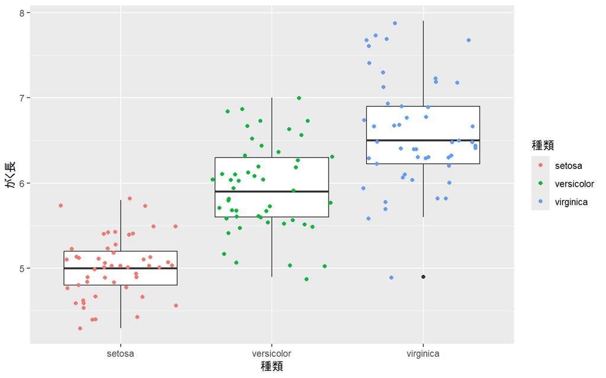

```r
g<- ggplot(data_iris)+
  geom_boxplot(aes(x=種類,y=がく長))+
  geom_jitter(aes(x=種類, y=がく長, color=種類))
plot(g)
```

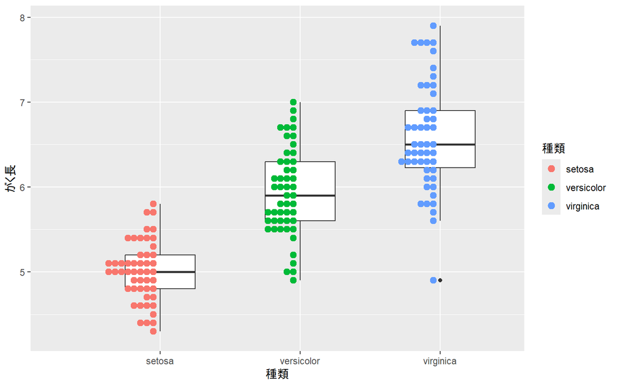

```r
g<- ggplot(data_iris)+
  geom_boxplot(aes(x=種類,y=がく長), width=0.5)+
  geom_dotplot(aes(x=種類, y=がく長, color=種類, fill=種類), binaxis = "y",
               dotsize = 0.75, stackdir = "down",binwidth = 0.1,
               position = position_nudge(-0.025))
plot(g)
```

`aes()`（エステティック）関数の設定項目はx、y軸とfill(塗りつぶし), color(線や点の色設定)が出てきているが、それ以外に以下のようなものがある。

| 項目 | 内容 |
| --- | --- |
| x, y | x軸に設定する変数、y軸に設定する変数 |
| color | 点や線の色 |
| fill | 面の色 |
| alpha | 不透明度 (0が透明、1が不透明) |
| size | 点や文字の大きさ、線の太さ |
| shape | 点の形 |
| linetype | 線の種類 |
| group | 反復試行の折れ線グラフなど、色や形はそのままで切り分けたいときに。 |
| xmin, xmax, ymin, ymax, xend, yend | ものによってつかう。 |

極めて多いエラーとして、各`geom()`関数を実行していくときに、前の行の末尾に`+`を付け忘れたり、最後の行の末尾に`+`をつけたりしてしまうことがよくある。 もし、エラーが出てグラフ描画ができなかった場合には、これらのミスをしていないかを確認してみてほしい。

## 5.3 棒グラフ

平均や標準偏差が得られているなら棒グラフとしてそれらを描きたい。その場合には、まずは平均と標準偏差のグループごとのデータを用意した上で、以下のようにする。

```r
#データの準備
d.mean <- aggregate(がく長~種類,data_iris, mean)
d.sd <- aggregate(がく長~種類,data_iris, sd)
d.mean
```

```
##         種類 がく長
## 1     setosa  5.006
## 2 versicolor  5.936
## 3  virginica  6.588
```

```r
d.sd
```

```
##         種類    がく長
## 1     setosa 0.3524897
## 2 versicolor 0.5161711
## 3  virginica 0.6358796
```

```r
d2 <- data.frame(
  種類 = d.mean$種類,
  平均 = d.mean$がく長,
  標準偏差= d.sd$がく長
)
print(d2)
```

```
##         種類  平均  標準偏差
## 1     setosa 5.006 0.3524897
## 2 versicolor 5.936 0.5161711
## 3  virginica 6.588 0.6358796
```

[figure not shown]

```r
 g <- ggplot(d2)+
  geom_bar(aes(x=種類,y=平均,fill=種類),stat="identity")+
  geom_errorbar(aes(x=種類,y=平均,ymin=平均-標準偏差, ymax=平均+標準偏差,width=0.15))
plot(g)
```

さらに、平均値自体を棒グラフに重ねて記述したい場合には以下のようにする。vjustは、テキストの位置を調整するためのパラメータで、数値が大きいほど下に移動する。負の値にした場合は棒グラフよりも上の表記される。

[figure not shown]

```r
g <- ggplot(d2)+
  geom_bar(aes(x=種類,y=平均,fill=種類),stat="identity")+
  geom_errorbar(aes(x=種類,y=平均,ymin=平均-標準偏差, ymax=平均+標準偏差,width=0.15))+
  geom_text(aes(x=種類,y=平均,label=round(平均,1)),vjust=5)
plot(g)
```

今まで、キャンバスを作った際にデータフレームを与え、その後、描画をする際にxとyを指摘してきたが、キャンバスを作るときにxとyも指定することができる。そうすると、描画をするときに、いちいちx、yを指定しなくても良くなる。以下に例を示す。

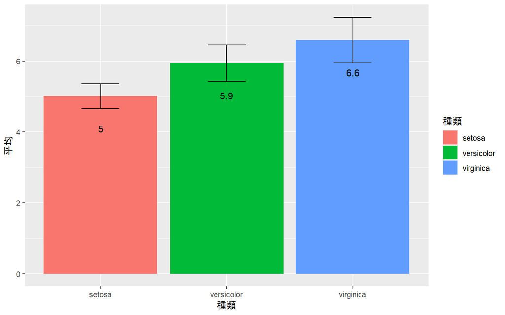

```r
g <- ggplot(d2)+
  geom_bar(aes(x=種類,y=平均,fill=種類),stat="identity")+
  geom_errorbar(aes(x=種類,y=平均,ymin=平均-標準偏差, ymax=平均+標準偏差,width=0.3))+
  geom_text(aes(x=種類,y=平均,label=round(平均,1)),vjust=5)
plot(g)
```

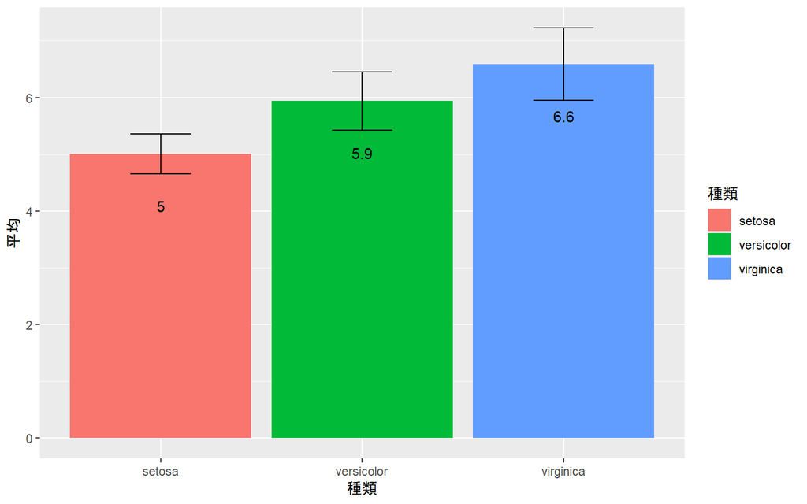

```r
g <- ggplot(d2,aes(x=種類,y=平均))+
  geom_bar(aes(fill=種類),stat="identity")+
  geom_errorbar(aes(ymin=平均-標準偏差, ymax=平均+標準偏差,width=0.3))+
  geom_text(aes(label=round(平均,1)),vjust=5)
plot(g)
```

## 5.4 ヒストグラム

ヒストグラムを作成する方法は2つある。

1. `geom_bar()`で`stat`を`count`に設定する。
2. `geom_histgram()`を使う

### 5.4.1 geom_bar()を使う

度数分布をグラフ表示したものをヒストグラムと呼ぶ。ヒストグラムは棒グラフの派生形として、以下のように、`stat`を`count`に設定することで描くことができる。ただし、この場合には区間幅を自分で設定することはできない。

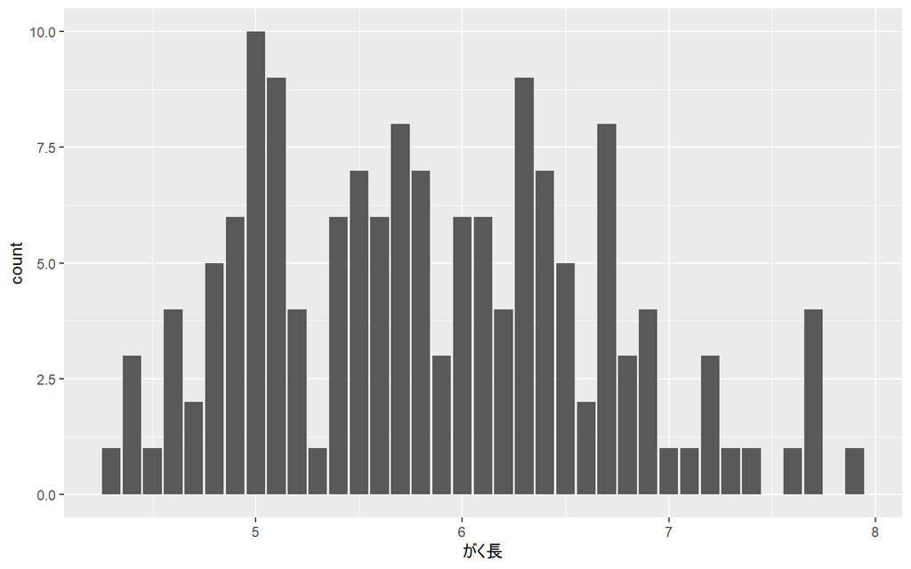

```r
g <- ggplot(data_iris)+
  geom_bar(aes(x=がく長),stat="count")
plot(g)
```

### 5.4.2 geom_histgram()を使う

`geom_histgram`を使う場合、区間幅はデフォルトではデータの範囲を30等分した値が自動的に設定されるが、`binwidth`を設定することによって任意の区間幅に設定することもできる。

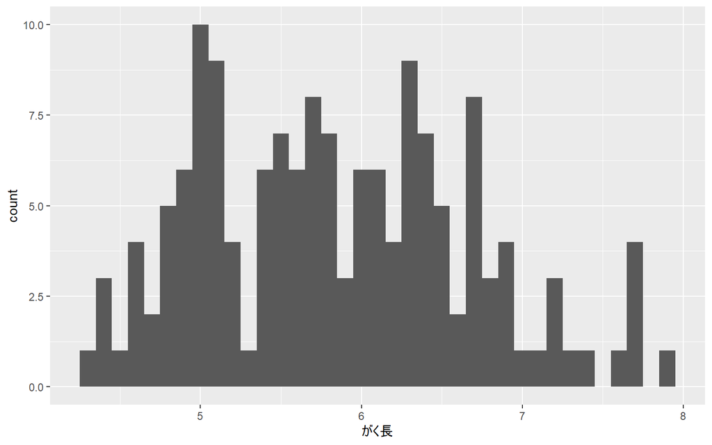

```r
g <- ggplot(data_iris)+
  geom_histogram(aes(x=がく長), binwidth = 0.1)
plot(g)
```

これだと区間の境界がわかりにくいので、境界を描かせるためには以下のようにする。

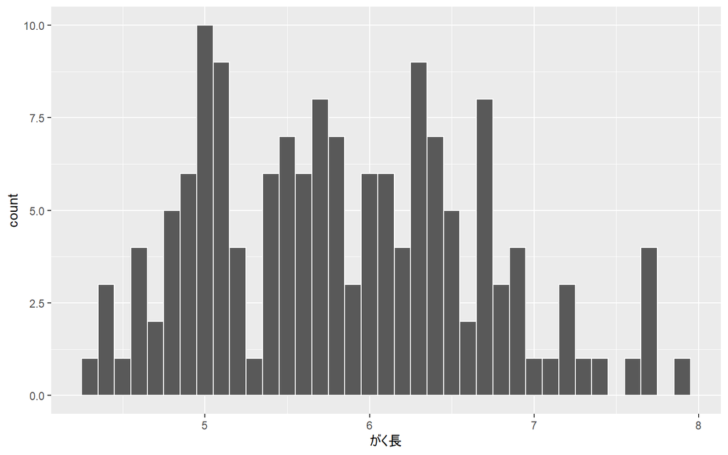

```r
g <- ggplot(data_iris)+
  geom_histogram(aes(x=がく長),color="white", binwidth = 0.1)
plot(g)
```

### 5.4.3 種類ごとの色分け

種類ごとに分けて分布表を作る場合は、`geom_bar`にせよ、`geom_histgram`にせよ`aes()`の中で`fill`を設定する。

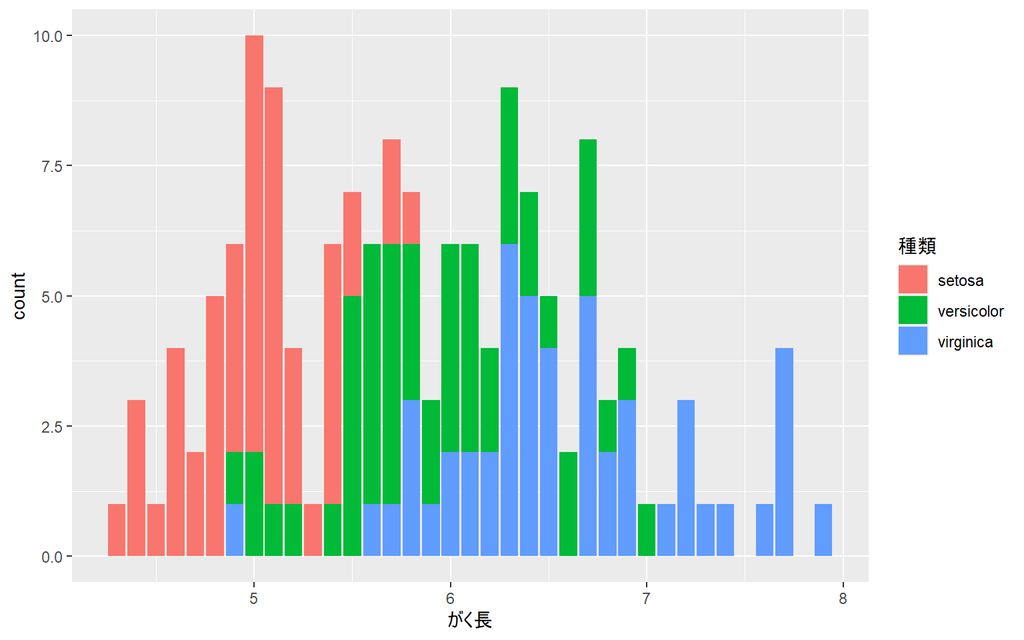

```r
g <- ggplot(data_iris)+
  geom_bar(aes(x=がく長, fill=種類),stat="count")
plot(g)
```

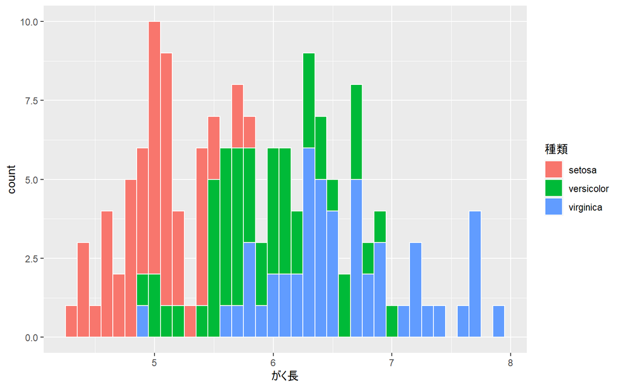

```r
g <- ggplot(data_iris)+
  geom_histogram(aes(x=がく長, fill=種類),color="white", binwidth = 0.1)
plot(g)
```

### 5.4.4 種類別のヒストグラム作成

あくまで種類ごとにそれぞれ別々のヒストグラムにしたい、ということであれば、以下のように2つの方法が考えられる。

**方法1 データを端からバラバラにして3つのグラフを別々に描く**

この場合には、データを`filter()`関数(->参考)を用いて種類ごとに分け、それぞれを描画する。ただし、この場合、`coord_cartesian(xlim =)`関数を使ってx軸の変域を設定しないと、3つのグラフのx軸の変域がバラバラになってしまう。

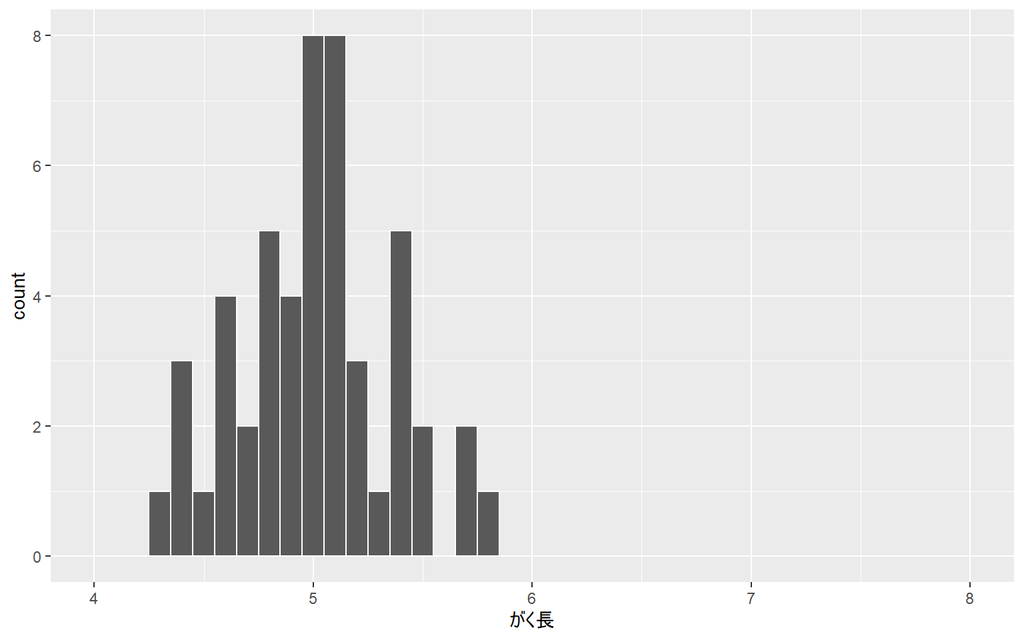

```r
g <- ggplot(filter(data_iris,種類=="setosa"))+
  geom_histogram(aes(x=がく長),color="white", binwidth = 0.1)+
  coord_cartesian(xlim = c(4, 8))
plot(g)
```

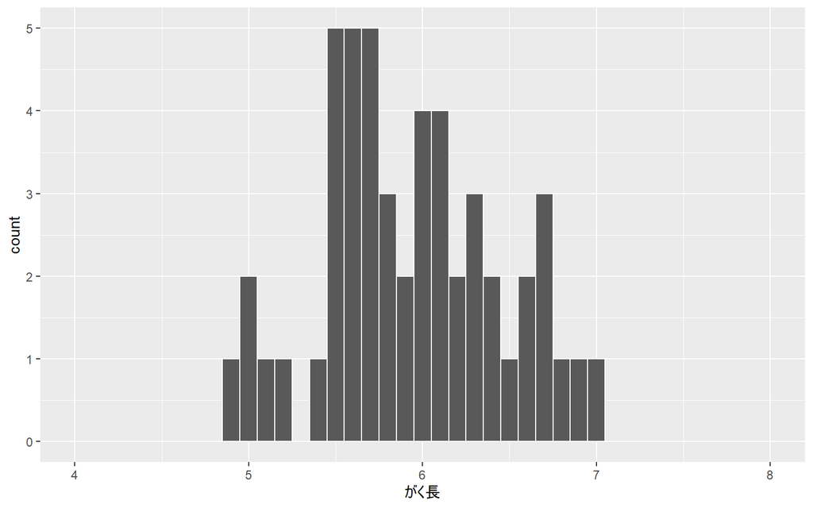

```r
g <- ggplot(filter(data_iris,種類=="versicolor"))+
  geom_histogram(aes(x=がく長),color="white", binwidth = 0.1)+
  coord_cartesian(xlim = c(4, 8))
plot(g)
```

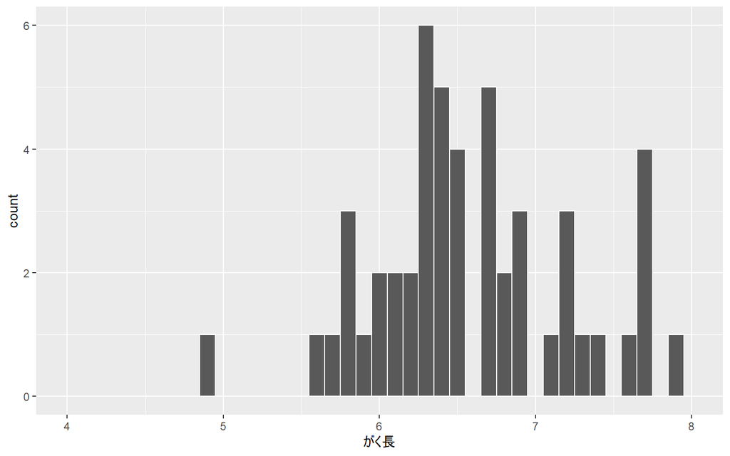

```r
g <- ggplot(filter(data_iris,種類=="virginica") )+
  geom_histogram(aes(x=がく長),color="white", binwidth = 0.1)+
  coord_cartesian(xlim = c(4, 8))
plot(g)
```

変数の内容を知るための関数として`str()`という関数がある。実際にこれを`filter()`関数の結果に対してかけてみると、以下の通りとなる。

```r
res<-filter(data_iris,種類=="setosa")
str(res)
```

```
## 'data.frame':    50 obs. of  5 variables:
##  $ がく長  : num  5.1 4.9 4.7 4.6 5 5.4 4.6 5 4.4 4.9 ...
##  $ がく幅  : num  3.5 3 3.2 3.1 3.6 3.9 3.4 3.4 2.9 3.1 ...
##  $ 花びら長: num  1.4 1.4 1.3 1.5 1.4 1.7 1.4 1.5 1.4 1.5 ...
##  $ 花びら幅: num  0.2 0.2 0.2 0.2 0.2 0.4 0.3 0.2 0.2 0.1 ...
##  $ 種類    : Factor w/ 3 levels "setosa","versicolor",..: 1 1 1 1 1 1 1 1 1 1 ...
```

データ点数は50点とあり、確かにsetosaのみを取り出せているのがわかる。一方で「種類」列の情報としては、この列は要因型であり、3つの水準（setosa, versicolorだけが表示されているが・・・）で構成されていることが記載されていることがわかる。

**方法2: 1つの絵の中で3つに分割して描く(`facet_wrap()`の利用)**

`facet_wrap()`を利用することで1枚のキャンバスを分割して表示させることができる。

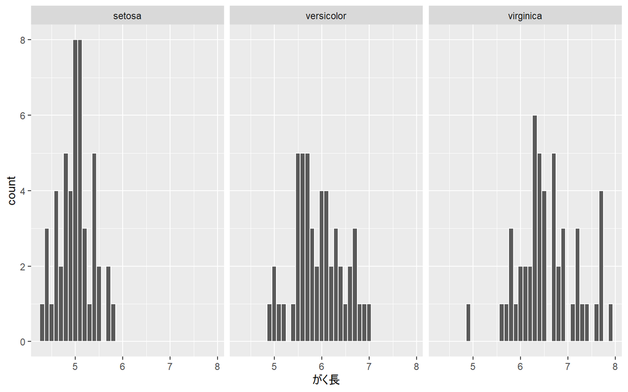

```r
g <- ggplot(data_iris)+
  geom_histogram(aes(x=がく長),color="white", binwidth = 0.1)+
    facet_wrap(data_iris$種類)
plot(g)
```

デフォルトでは、横方向（列方向）に分割されていくが、`nrow`(行数)を設定することによって縦方向（行方向）にも分割させることができる。

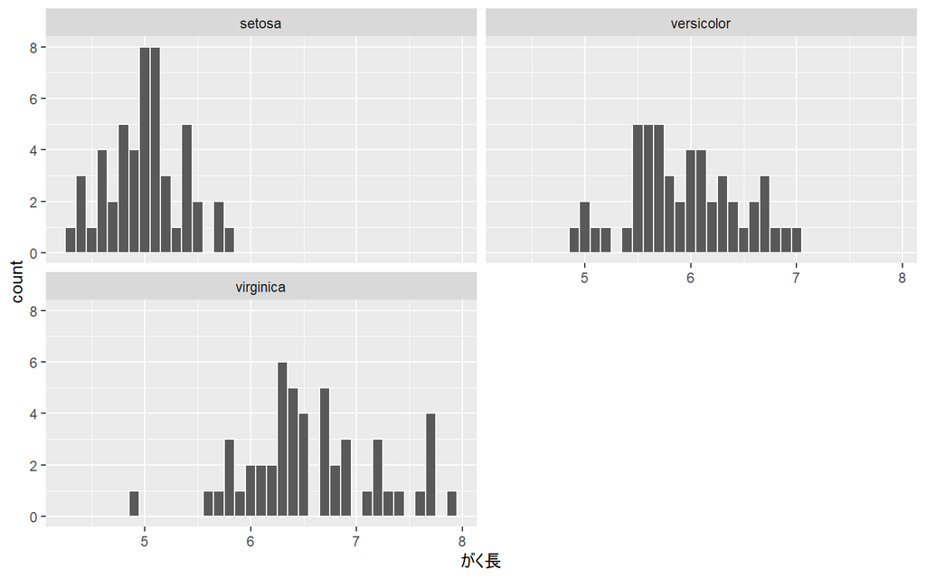

```r
g <- ggplot(data_iris)+
  geom_histogram(aes(x=がく長),color="white", binwidth = 0.1)+
    facet_wrap(data_iris$種類,nrow=2)
plot(g)
```